# Análisis Exploratorio

Datos, Ciencia y Sociedad. Grado Ciencia de Datos. ETSE-UV.

# Distribución de probabilidad

Valores aletorios $x$ según una distribución de aleatoria normal centrada de media 0 y desviación estándar 1.

```r
set.seed(666)
x<-rnorm(n=1000,mean=0,sd=1) #valores aleatorios centrados en 0 y sd=1
```

Discretizamos la variable continua por intervalos y obtenemos su frecuencia.

```r
x.intervalo<-cut(x,breaks = seq(from=-4,to=4,by = 0.5)) #troceamos la variable continua por intervalos
x.freq<-table(x.intervalo) #summary(x.intervalo)
x.freq
```

```
## x.intervalo
## (-4,-3.5] (-3.5,-3] (-3,-2.5] (-2.5,-2] (-2,-1.5] (-1.5,-1] (-1,-0.5]  (-0.5,0]
##         0         3         5        14        48        83       165       179
##   (0,0.5]   (0.5,1]   (1,1.5]   (1.5,2]   (2,2.5]   (2.5,3]   (3,3.5]   (3.5,4]
##       188       166        92        36        18         3         0         0
```

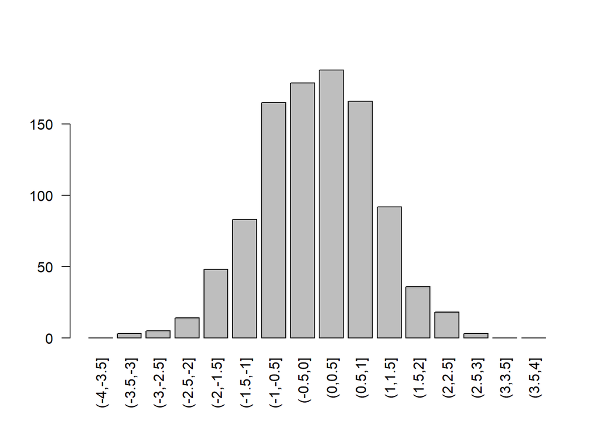

```r
barplot(table(x.intervalo),las=2)
```

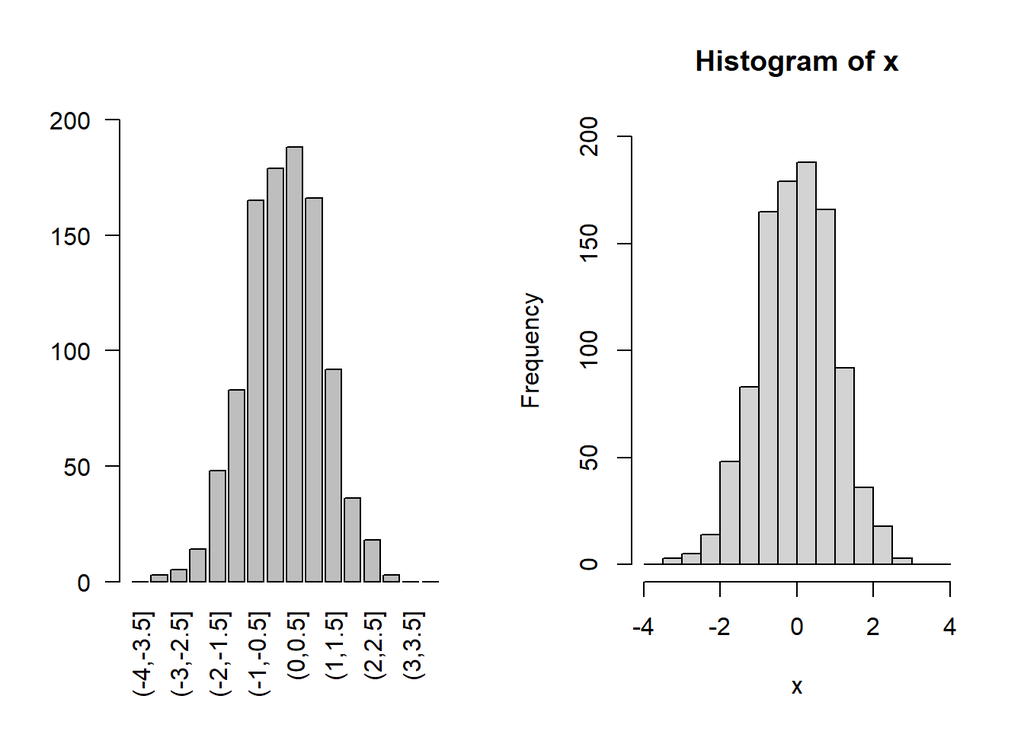

```r
# mismo resultado con solo una instruccion
par(mfrow=c(1,2))
barplot(table(x.intervalo),las=2,ylim=c(0,200))
hist(x,freq = TRUE,breaks = seq(from=-4,to=4,by = 0.5),ylim=c(0,200))
```

La densidad de probabilidad es la frecuencia normalizada para que el área sume 1 (area=suma de rectángulos de ancho 0.5 y alto igual a la frecuencia normalizada) .

```r
par(mfrow=c(1,2))
densidad<-table(x.intervalo)/sum(table(x.intervalo))/(0.5)
probabilidad=densidad*0.5
sum(probabilidad)
```

```
## [1] 1
```

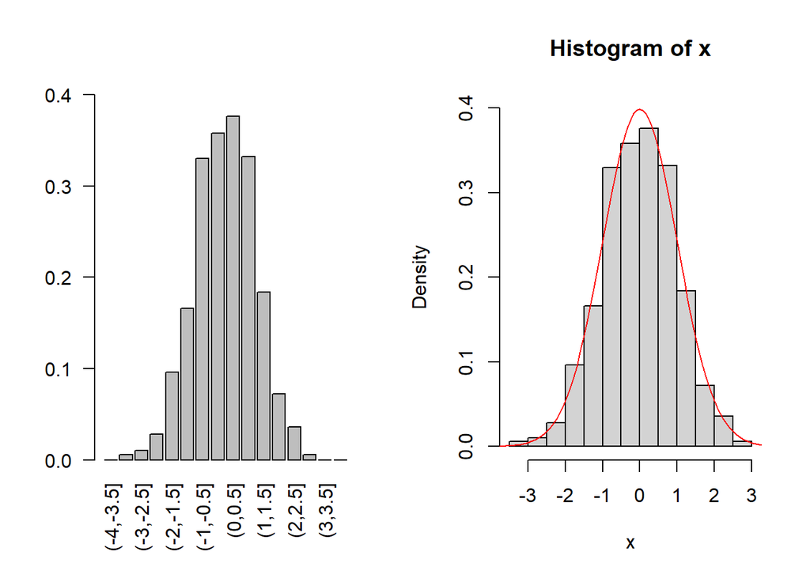

```r
barplot(densidad,las=2,ylim=c(0,0.4)) #los intervalos son de 0.5 anchos
hist(x,freq = FALSE,ylim=c(0,0.4))
curve(dnorm(x),-4,4,col="red",add = T)
```

# Población y Muestra

```r
set.seed(666) #inicio de la semilla del generador aleatorio
poblacion<-LETTERS
poblacion
```

```
##  [1] "A" "B" "C" "D" "E" "F" "G" "H" "I" "J" "K" "L" "M" "N" "O" "P" "Q" "R" "S"
## [20] "T" "U" "V" "W" "X" "Y" "Z"
```

```r
muestra<-sample(x=poblacion,size=5,replace=TRUE)
muestra
```

```
## [1] "K" "N" "E" "I" "L"
```

# Estadístico

## Clásicos

Resumen de los datos basado en el valor.

```r
x<-c(50,0:10,-5)
mean(x) #valor medio, comentar! mean(x,trim = 0.1) #weighted.mean(x,w=c(0,rep(1,11),0))
```

```
## [1] 7.692308
```

```r
sd(x) #desviación estándar
```

```
## [1] 13.35655
```

```r
estadisticos.clasicos<-c(media=mean(x),sd=sd(x))
estadisticos.clasicos
```

```
##     media        sd
##  7.692308 13.356550
```

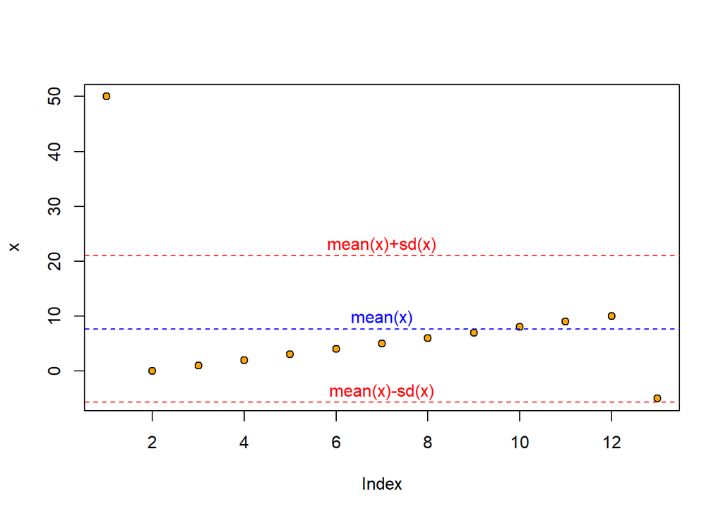

```r
plot(x,pch=21,bg="orange")
abline(h=mean(x),lty=2,col="blue")
abline(h=mean(x)+sd(x),lty=2,col="red")
abline(h=mean(x)-sd(x),lty=2,col="red")

text(7,mean(x)+2,"mean(x)",col="blue")
text(7,mean(x)+sd(x)+2,"mean(x)+sd(x)",col="red")
text(7,mean(x)-sd(x)+2,"mean(x)-sd(x)",col="red")
```

## Robustos

Resumen de los datos basado en la posición del valor (rango).

```r
x<-c(50,0:10,-5)
x[rank(x)] #cada valor en su rango=valores ordenados!!
```

```
##  [1] -5  0  1  2  3  4  5  6  7  8  9 10 50
```

Cuantiles

```r
quantile(x,probs = c(0,0.25,0.5,0.75,1))
```

```
##   0%  25%  50%  75% 100%
##   -5    2    5    8   50
```

```r
#otra manera de verlo
percentiles<-quantile(x,probs = c(0,0.25,0.5,0.75,1))
names(percentiles)<-c("minimo","Q1","Q2","Q3","máximo")
percentiles
```

```
## minimo     Q1     Q2     Q3 máximo
##     -5      2      5      8     50
```

```r
median(x) #mediana o percentil 50%
```

```
## [1] 5
```

```r
estadisticos.robustos<-c(mediana=median(x),IQR=IQR(x))
estadisticos.robustos
```

```
## mediana     IQR
##       5       6
```

## Clásicos vs Robustos

- Clásicos más conocidos y tienen mejores propiedades mátemáticas.
- Robústos menos dependientes de valores erróneos o extremos.

```r
estadisticos.clasicos
```

```
##     media        sd
##  7.692308 13.356550
```

```r
estadisticos.robustos
```

```
## mediana     IQR
##       5       6
```

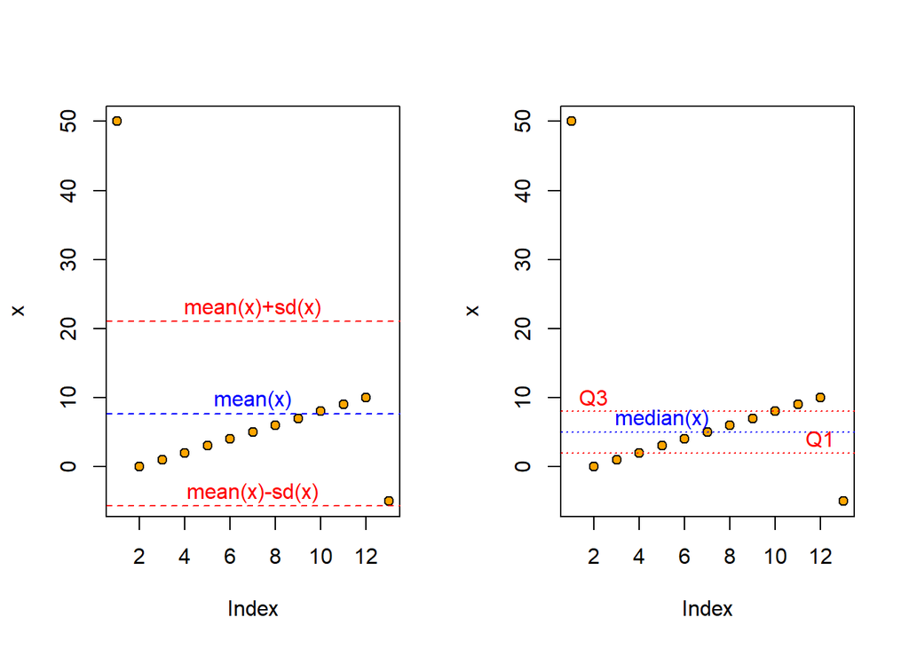

```r
par(mfrow=c(1,2))
plot(x,pch=21,bg="orange")
abline(h=mean(x),lty=2,col="blue")
abline(h=mean(x)+sd(x),lty=2,col="red")
abline(h=mean(x)-sd(x),lty=2,col="red")
text(7,mean(x)+2,"mean(x)",col="blue")
text(7,mean(x)+sd(x)+2,"mean(x)+sd(x)",col="red")
text(7,mean(x)-sd(x)+2,"mean(x)-sd(x)",col="red")

plot(x,pch=21,bg="orange")
abline(h=quantile(x,0.5) ,lty=3,col="blue")
abline(h=quantile(x,0.75),lty=3,col="red")
abline(h=quantile(x,0.25),lty=3,col="red")
text(5,median(x)+2,"median(x)",col="blue")
text(2,quantile(x,0.75)+2,"Q3",col="red")
text(12,quantile(x,0.25)+2,"Q1",col="red")
```

# Valores anomales

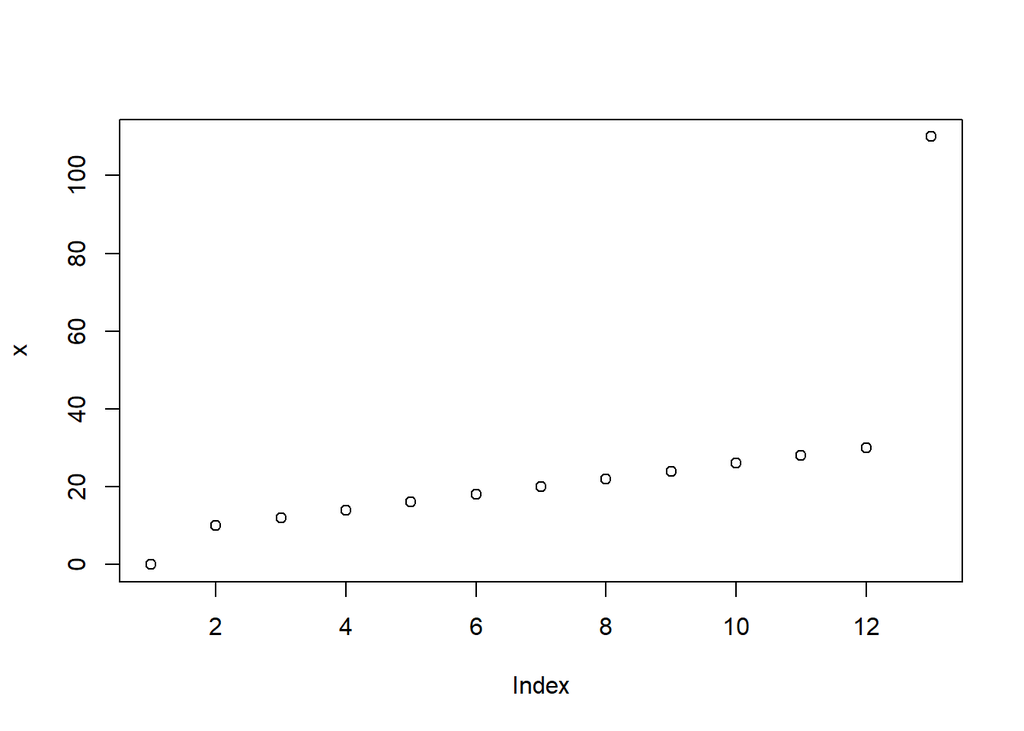

```r
x<-c(-5,0:10,50)*2+10 #x<-c(-5,seq(0,10,by=0.0001),1e+10)*2+100
plot(x)
```

```r
#mean(x) #valor medio
#sd(x) #desviación estándar
z.abs<-abs((x-mean(x))/sd(x)) #variable tipificada
z.abs
```

```
##  [1] 0.95026840 0.57592024 0.50105061 0.42618098 0.35131135 0.27644172
##  [7] 0.20157209 0.12670245 0.05183282 0.02303681 0.09790644 0.17277607
## [13] 3.16756134
```

```r
z.abs<3 #no outliers
```

```
##  [1]  TRUE  TRUE  TRUE  TRUE  TRUE  TRUE  TRUE  TRUE  TRUE  TRUE  TRUE  TRUE
## [13] FALSE
```

```r
z.abs>=3 #outliers
```

```
##  [1] FALSE FALSE FALSE FALSE FALSE FALSE FALSE FALSE FALSE FALSE FALSE FALSE
## [13]  TRUE
```

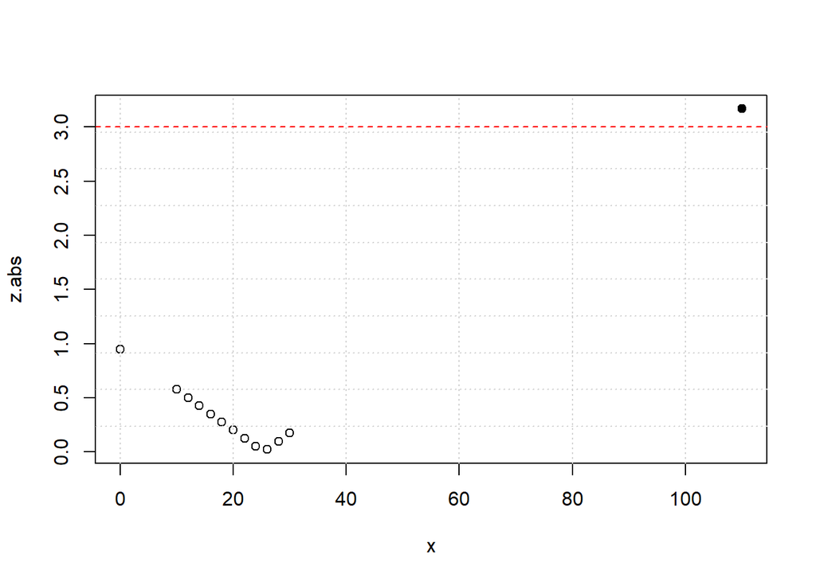

```r
plot(x,z.abs,pch=21,bg=(z.abs>3))
abline(h=3,col="red",lty=2)
grid(ny=10)
```

# Coeficiente de correlación

Mide la relación lineal de dos variables (acotado entre -1 y 1)

```r
x<-seq(-10,10,0.1)
y<-x^3
plot(x,y,main="Coeficiente de correlació")
cor(x,y) #coeficiente de correlación
```

```
## [1] 0.9165303
```

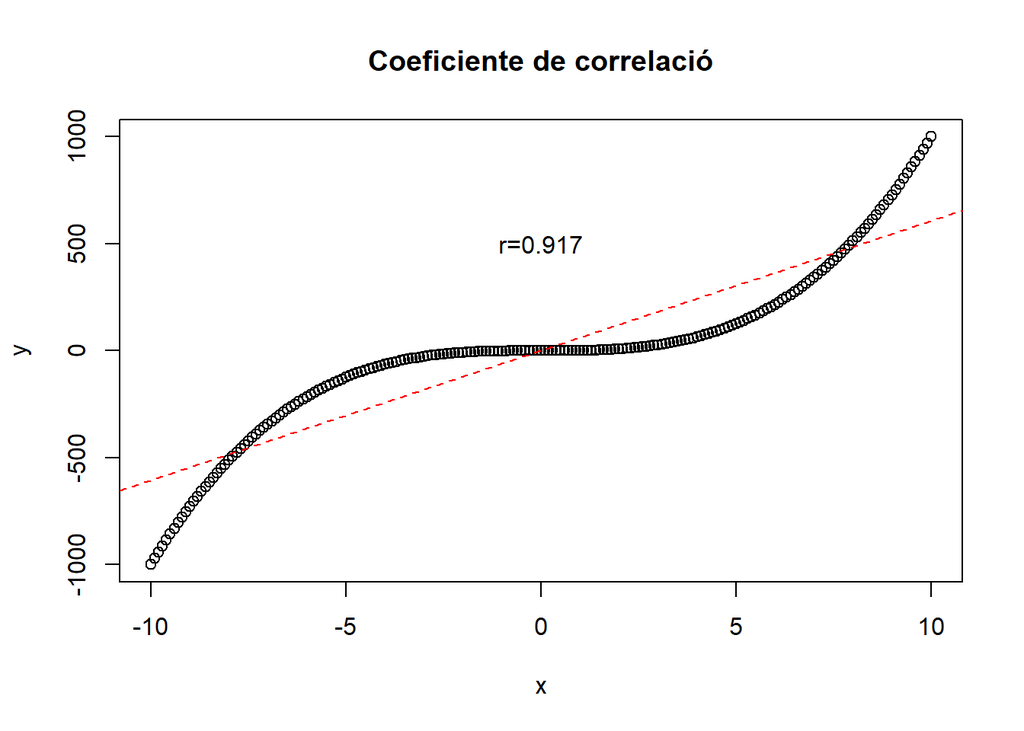

```r
abline(lm(y~x),col="red",lty=2) #representa una recta que se ajusta a los datos
text(x=0,y=500,paste0("r=",round(cor(x,y),digits = 3)))
```

```r
#cor(x,y,method = "spearman")#=cor(rank(x),rank(y));
```

# Asociación

## Variables independientes

Estadístico $\chi^2$ pequeño indica independencia.

```r
set.seed(666)

n=500
prob.moneda<-c(0.5,0.5)
moneda<-sample(c("cara","cruz"),size=n,replace = T,prob=prob.moneda)
prob.momento<-c(4,0.5)/4.5 #4 horas de clase y media hora de descanso
momento<-sample(c("clase","descanso"),size=n,replace = T,prob=prob.momento)
observado<-table(moneda,momento)
observado
```

```
##       momento
## moneda clase descanso
##   cara   231       26
##   cruz   221       22
```

```r
#esperado.teorico<-prob.moneda%*%t(prob.momento)*n #teórica
prob.moneda.sample<-prop.table(margin.table(observado,1)) #prob.moneda
prob.momento.sample<-prop.table(margin.table(observado,2)) #prob.momento
esperado<-prob.moneda.sample%*%t(prob.momento.sample)*n
esperado
```

```
##       momento
## moneda   clase descanso
##   cara 232.328   24.672
##   cruz 219.672   23.328
```

```r
#medida de asociación chi2
chi2<-sum((observado-esperado)^2/esperado)
chi2
```

```
## [1] 0.1626998
```

```r
chisq.test(observado,correct = F)
```

```
##
##  Pearson's Chi-squared test
##
## data:  observado
## X-squared = 0.1627, df = 1, p-value = 0.6867
```

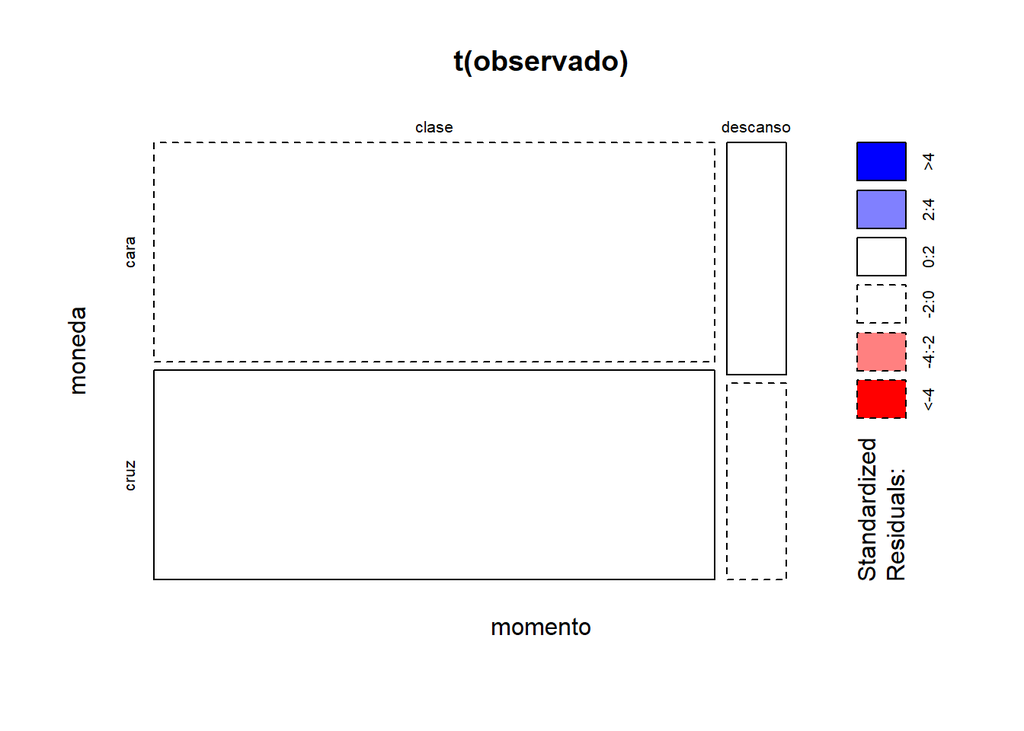

```r
mosaicplot(t(observado),shade=T)
```

## Variables dependientes

Estadístico $\chi^2$ grande indica dependencia.

```r
set.seed(666)

n=500
dado<-sample.int(6,size=n,replace = T)
impar<-dado%%2
observado<-table(dado,impar)
observado
```

```
##     impar
## dado  0  1
##    1  0 86
##    2 79  0
##    3  0 77
##    4 91  0
##    5  0 81
##    6 86  0
```

```r
prob.dado.sample<-prop.table(margin.table(observado,1)) #prob.dado
prob.impar.sample<-prop.table(margin.table(observado,2)) #prob.impar
esperado<-prob.dado.sample%*%t(prob.impar.sample)*n
esperado
```

```
##     impar
## dado      0      1
##    1 44.032 41.968
##    2 40.448 38.552
##    3 39.424 37.576
##    4 46.592 44.408
##    5 41.472 39.528
##    6 44.032 41.968
```

```r
#medida de asociación chi2
chi2<-sum((observado-esperado)^2/esperado)
chi2
```

```
## [1] 500
```

```r
chisq.test(observado,correct = F)
```

```
##
##  Pearson's Chi-squared test
##
## data:  observado
## X-squared = 500, df = 5, p-value < 2.2e-16
```

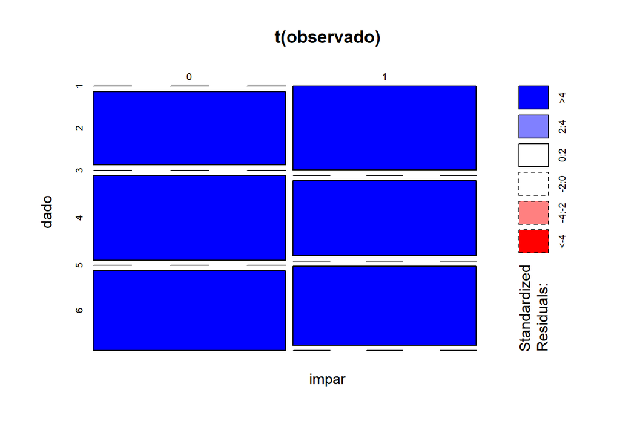

```r
mosaicplot(t(observado),shade=T)
```

# Tranformaciónes de instancias (filas)

## Balanceo de clases

```r
# Generación del data.frame
set.seed(666)
gripe<-sample(x=c("Gripe","NoGripe"), size=20, replace = TRUE, prob = c(0.1,0.9))
genero<-sample(x=c("Mujer","Hombre"), size=20, replace = TRUE, prob = c(0.5,0.5))
paciente<-data.frame(gripe,genero)

contingencia<-table(paciente$gripe,paciente$genero)
addmargins(contingencia)
```

```
##
##           Hombre Mujer Sum
##   Gripe        2     0   2
##   NoGripe      6    12  18
##   Sum          8    12  20
```

Quitaremos registros del Genero mayoritario para igualar el peso de los registros

```r
#eliminar<-which(paciente$genero=="Mujer")[1:5]
eliminar<-head(which(paciente$genero=="Mujer"),5)
paciente.balanceado<-paciente
paciente.balanceado<-paciente.balanceado[-eliminar,]

contingencia.balanceado<-table(paciente.balanceado$gripe,paciente.balanceado$genero)
addmargins(contingencia.balanceado)
```

```
##
##           Hombre Mujer Sum
##   Gripe        2     0   2
##   NoGripe      6     7  13
##   Sum          8     7  15
```

## Imputación de valores perdidos

```r
data<-matrix(c(1.1,2.3,4.5,8.9,
         2,3.2,9.7,NA,
         1.5,1.2,5.6,NA,
         2.1,3.3,9.9,4.6,
         5.6,NA,NA,NA,
         5.4,6.7,9.2,1.1,
         3.4,2.2,6.6,NA),byrow = T,ncol=4)
data<-as.data.frame(data)
rownames(data)<-paste0("PAC",1:7)
data
```

```
##       V1  V2  V3  V4
## PAC1 1.1 2.3 4.5 8.9
## PAC2 2.0 3.2 9.7  NA
## PAC3 1.5 1.2 5.6  NA
## PAC4 2.1 3.3 9.9 4.6
## PAC5 5.6  NA  NA  NA
## PAC6 5.4 6.7 9.2 1.1
## PAC7 3.4 2.2 6.6  NA
```

```r
#completar
any(is.na(data)) #hay nulos?
```

```
## [1] TRUE
```

```r
na.row<-apply(is.na(data),1,sum) #nulos por registro
data[complete.cases(data),] #conjunto completo
```

```
##       V1  V2  V3  V4
## PAC1 1.1 2.3 4.5 8.9
## PAC4 2.1 3.3 9.9 4.6
## PAC6 5.4 6.7 9.2 1.1
```

```r
data.clean<-data[na.row<=1,] #eliminamos el PAC con más de un nulo

mean.V4<-mean(data.clean$V4,na.rm = TRUE)
data.clean[is.na(data.clean$V4),]<-mean.V4
#data
data.clean
```

```
##            V1       V2       V3       V4
## PAC1 1.100000 2.300000 4.500000 8.900000
## PAC2 4.866667 4.866667 4.866667 4.866667
## PAC3 4.866667 4.866667 4.866667 4.866667
## PAC4 2.100000 3.300000 9.900000 4.600000
## PAC6 5.400000 6.700000 9.200000 1.100000
## PAC7 4.866667 4.866667 4.866667 4.866667
```

# Transformaciones de variables (columnas)

## Codificación o *dummificar*

```r
set.seed(666)
vocal<-sample(x=c("A","E","I","O","U"), size=20, replace = TRUE)
vocal<-factor(vocal,ordered = FALSE)
summary(vocal)
```

```
## A E I O U
## 4 3 5 4 4
```

```r
vocal
```

```
##  [1] I I O U A O A E I U U O I E A E A O I U
## Levels: A E I O U
```

Una posibilidad de codificar aprovechando que es factor

```r
vocal.codificada<-as.numeric(vocal)
vocal.codificada
```

```
##  [1] 3 3 4 5 1 4 1 2 3 5 5 4 3 2 1 2 1 4 3 5
```

Dumificar una variable (también conocido como one-hot-encoding)

```r
vocal.dummy<-as.data.frame(matrix(0L,ncol=5,nrow = 20))
names(vocal.dummy)<-c("A","E","I","O","U")
#solucion
vocal.dummy[,"A"]<-ifelse(vocal=="A",1L,0L)
vocal.dummy[,"E"]<-ifelse(vocal=="E",1L,0L)
vocal.dummy[,"I"]<-ifelse(vocal=="I",1L,0L)
vocal.dummy[,"O"]<-ifelse(vocal=="O",1L,0L)
vocal.dummy$U<-as.integer(vocal=="U")
vocal.dummy
```

```
##    A E I O U
## 1  0 0 1 0 0
## 2  0 0 1 0 0
## 3  0 0 0 1 0
## 4  0 0 0 0 1
## 5  1 0 0 0 0
## 6  0 0 0 1 0
## 7  1 0 0 0 0
## 8  0 1 0 0 0
## 9  0 0 1 0 0
## 10 0 0 0 0 1
## 11 0 0 0 0 1
## 12 0 0 0 1 0
## 13 0 0 1 0 0
## 14 0 1 0 0 0
## 15 1 0 0 0 0
## 16 0 1 0 0 0
## 17 1 0 0 0 0
## 18 0 0 0 1 0
## 19 0 0 1 0 0
## 20 0 0 0 0 1
```

```r
#solucion 2
vocal.dummy2<-as.data.frame(matrix(0L,ncol=5,nrow = 20))
names(vocal.dummy2)<-c("A","E","I","O","U")
for (f in 1:20) {
  vocal.dummy2[f,vocal.codificada[f]]<-1
}
```

## Max-min

Transformaremos un valor aleatorio x en una variable de temperatura utilizando la transformación máximo-mínimo.

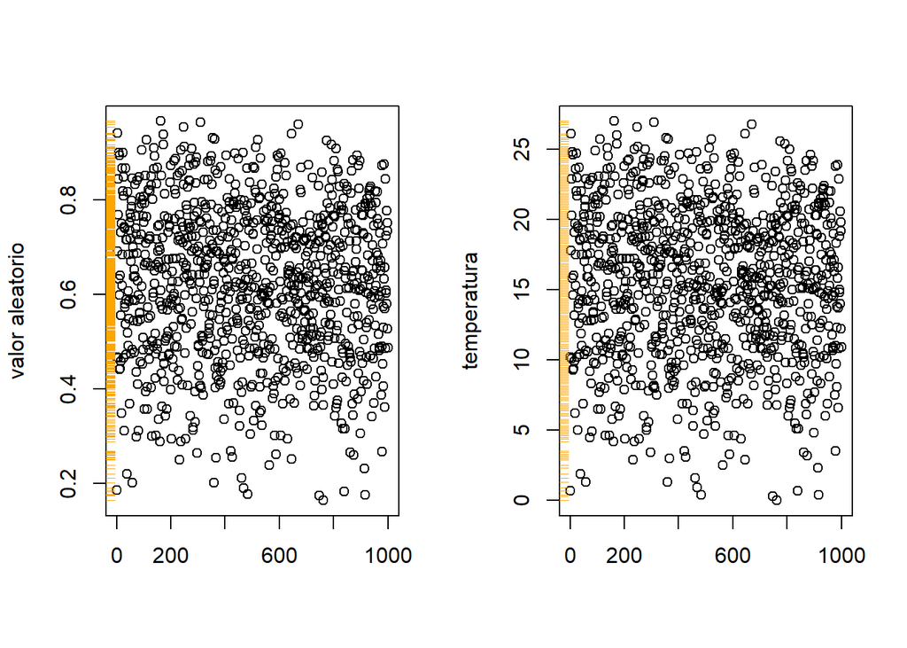

```r
set.seed(666)
x<-rbeta(n=1000,shape1=5,shape2=3) #valores aleatorio entre 0 y 1
x.min=min(x)
x.max=max(x)
y.min=0
y.max=27

#completar
temperatura<-(y.max-y.min)/(x.max-x.min)*(x-x.min)+y.min
temperatura<-round(temperatura,digits = 1) #más realista

par(mfrow=c(1,2))
plot(x,ylab="valor aleatorio",xlab = "");rug(x,side=2,col="orange")
plot(temperatura,xlab = "");rug(temperatura,side=2,col="orange")
```

```r
par(mfrow=c(1,1))
```

## Discretización

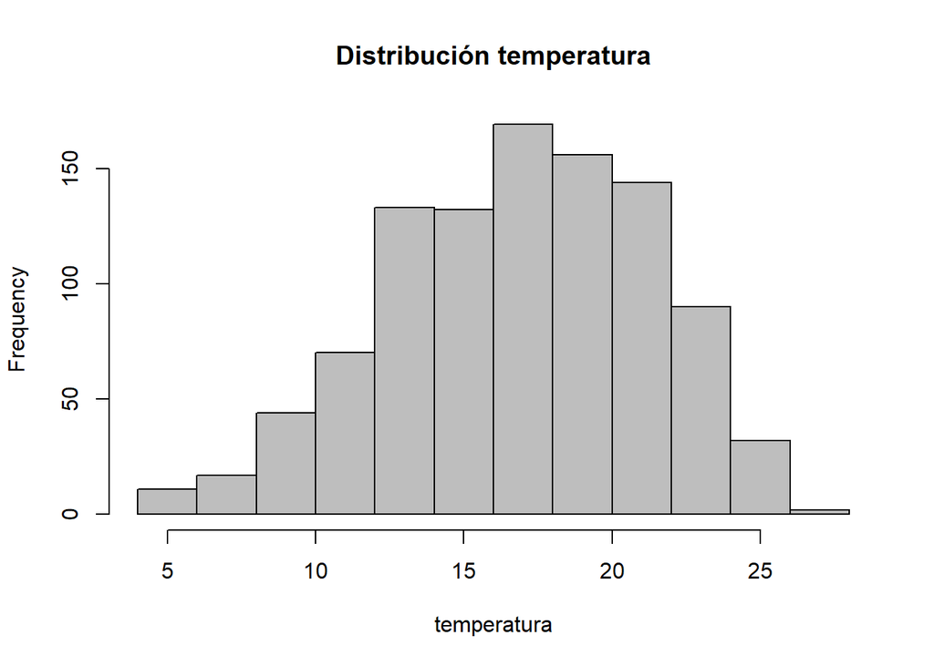

```r
set.seed(666)
x<-rbeta(n=1000,shape1=5,shape2=3) #valores aleatorio entre 0 y 1
x.min=0
x.max=1
y.min=0
y.max=27
temperatura<-(y.max-y.min)/(x.max-x.min)*(x-x.min)+y.min
hist(temperatura,main="Distribución temperatura",col="grey")
```

```r
#completar
temperatura.discreta<-cut(temperatura,c(-Inf,10,15,20,Inf))
summary(temperatura.discreta)
```

```
## (-Inf,10]   (10,15]   (15,20] (20, Inf]
##        72       262       398       268
```

```r
levels(temperatura.discreta)<-c("frío","fresquito","agradable","calorcito")
temperatura.discreta
```

```
##    [1] fresquito frío      agradable calorcito fresquito calorcito calorcito
##    [8] agradable calorcito fresquito calorcito agradable agradable fresquito
##   [15] fresquito agradable fresquito calorcito frío      agradable agradable
##   [22] calorcito calorcito calorcito calorcito calorcito fresquito calorcito
##   [29] frío      agradable agradable agradable fresquito calorcito agradable
##   [36] fresquito agradable agradable frío      fresquito calorcito agradable
##   [43] agradable fresquito fresquito agradable frío      calorcito agradable
##   [50] agradable calorcito agradable calorcito fresquito calorcito calorcito
##   [57] calorcito frío      fresquito agradable agradable fresquito agradable
##   [64] agradable agradable fresquito agradable calorcito agradable calorcito
##   [71] agradable agradable frío      fresquito agradable calorcito agradable
##   [78] fresquito fresquito frío      agradable calorcito agradable calorcito
##   [85] agradable agradable calorcito fresquito fresquito agradable agradable
##   [92] agradable calorcito calorcito fresquito calorcito fresquito calorcito
##   [99] fresquito calorcito calorcito calorcito agradable frío      calorcito
```

[output cut: 129 more lines]

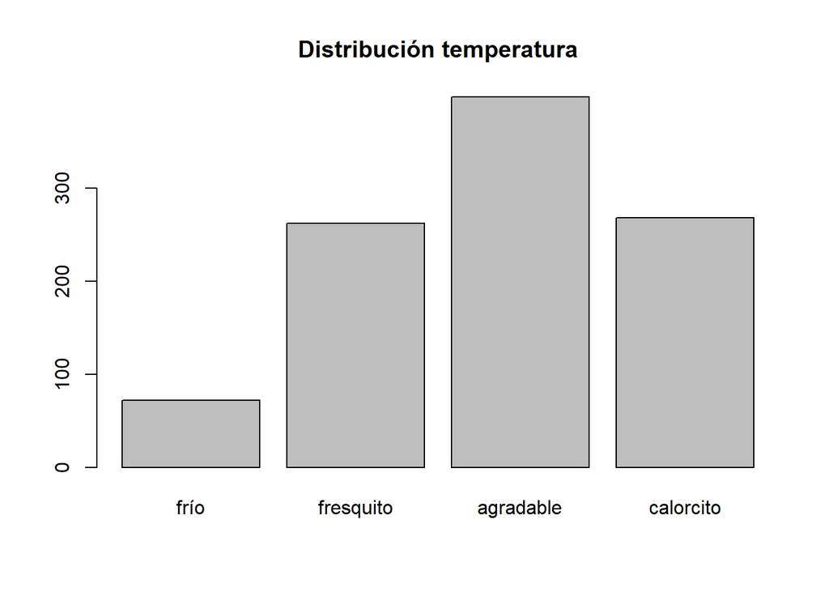

```r
plot(temperatura.discreta,main="Distribución temperatura")
```

# Visualización

## Histrograma

Representar el histograma de `Petal.width` para cada tipo de flor del Iris.

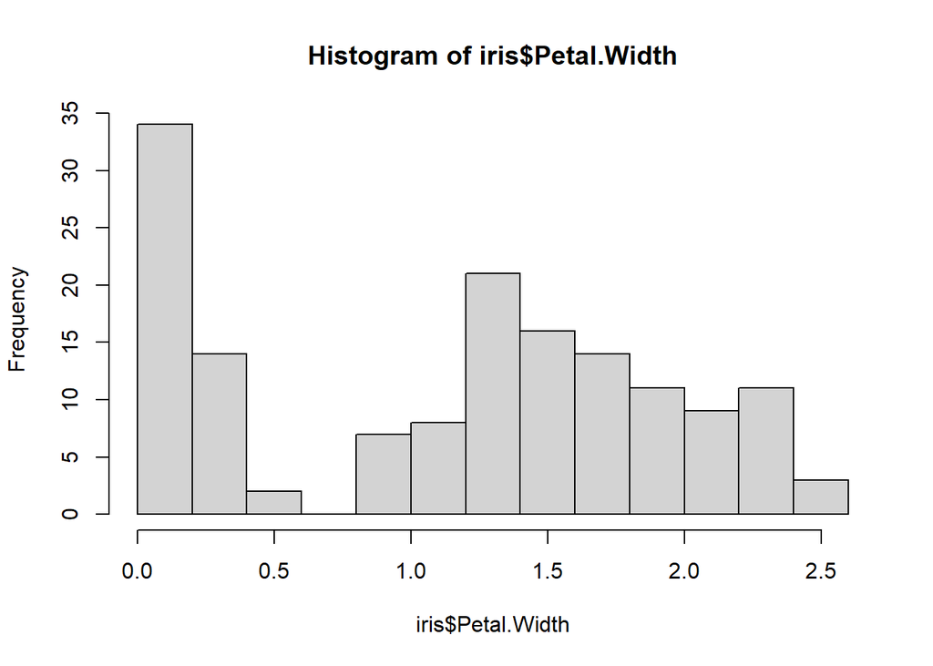

```r
data(iris)
hist(iris$Petal.Width,breaks = 10) #histograma con 10 particiones
```

```r
unique(iris$Species)
```

```
## [1] setosa     versicolor virginica
## Levels: setosa versicolor virginica
```

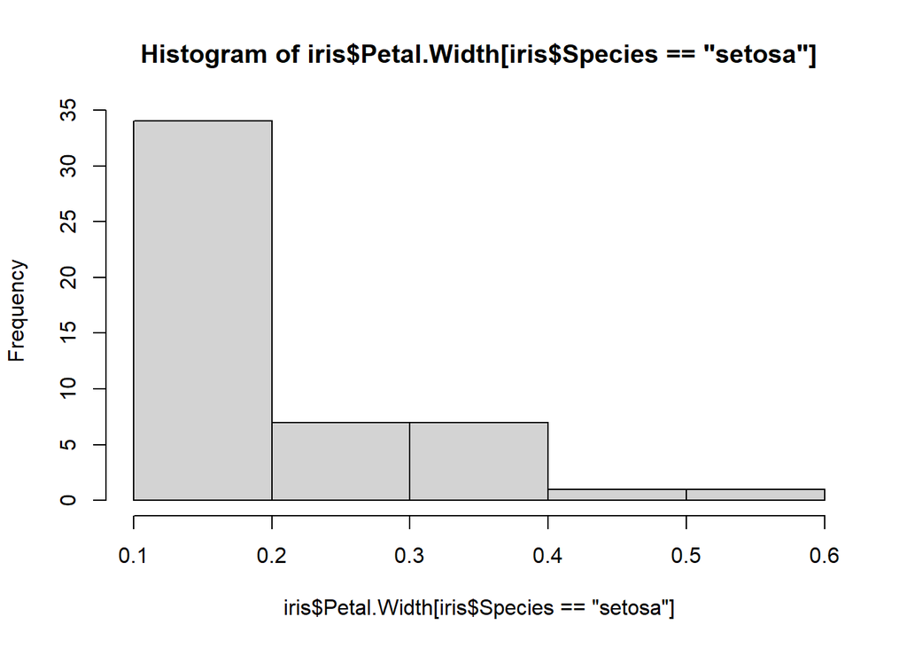

```r
#completar
h1<-hist(iris$Petal.Width[iris$Species=="setosa"])
```

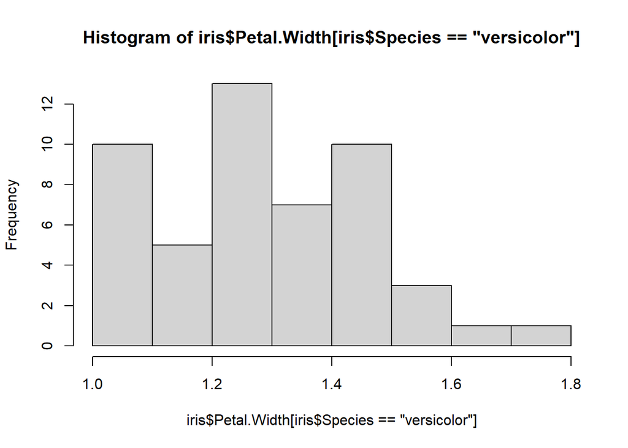

```r
h2<-hist(iris$Petal.Width[iris$Species=="versicolor"])
```

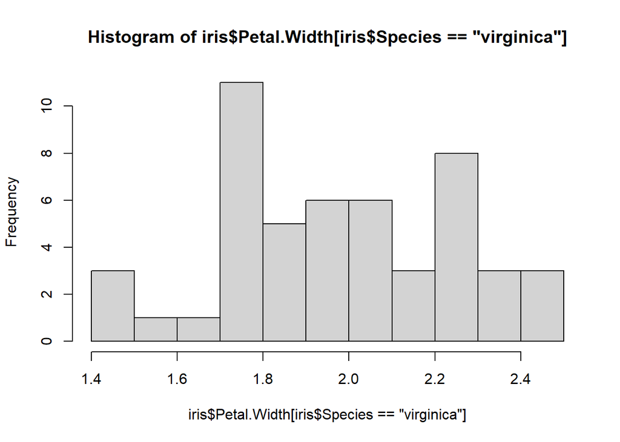

```r
h3<-hist(iris$Petal.Width[iris$Species=="virginica"],breaks = 10)
```

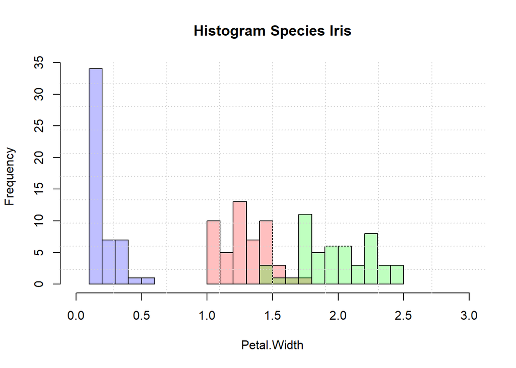

```r
plot( h1, col=rgb(0,0,1,1/4), xlim=c(0,3),main="Histogram Species Iris",xlab="Petal.Width")
plot( h2, col=rgb(1,0,0,1/4), xlim=c(0,3), add=TRUE)
plot( h3, col=rgb(0,1,0,1/4), xlim=c(0,3), add=TRUE)
grid(8,10)
```

## Boxplot

Distribución de valores de las medidas de las flores del Iris utilizando Boxplot.

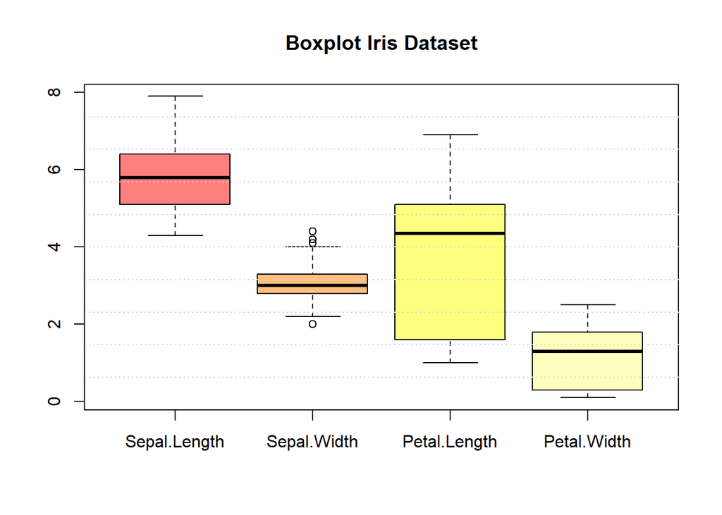

```r
data(iris)
#completar
boxplot(iris[,c(1:4)],col=heat.colors(4,alpha=0.5),main="Boxplot Iris Dataset")
grid(nx=0,ny=10)
```

## Scattering

```r
data("iris")
str(iris)
```

```
## 'data.frame':    150 obs. of  5 variables:
##  $ Sepal.Length: num  5.1 4.9 4.7 4.6 5 5.4 4.6 5 4.4 4.9 ...
##  $ Sepal.Width : num  3.5 3 3.2 3.1 3.6 3.9 3.4 3.4 2.9 3.1 ...
##  $ Petal.Length: num  1.4 1.4 1.3 1.5 1.4 1.7 1.4 1.5 1.4 1.5 ...
##  $ Petal.Width : num  0.2 0.2 0.2 0.2 0.2 0.4 0.3 0.2 0.2 0.1 ...
##  $ Species     : Factor w/ 3 levels "setosa","versicolor",..: 1 1 1 1 1 1 1 1 1 1 ...
```

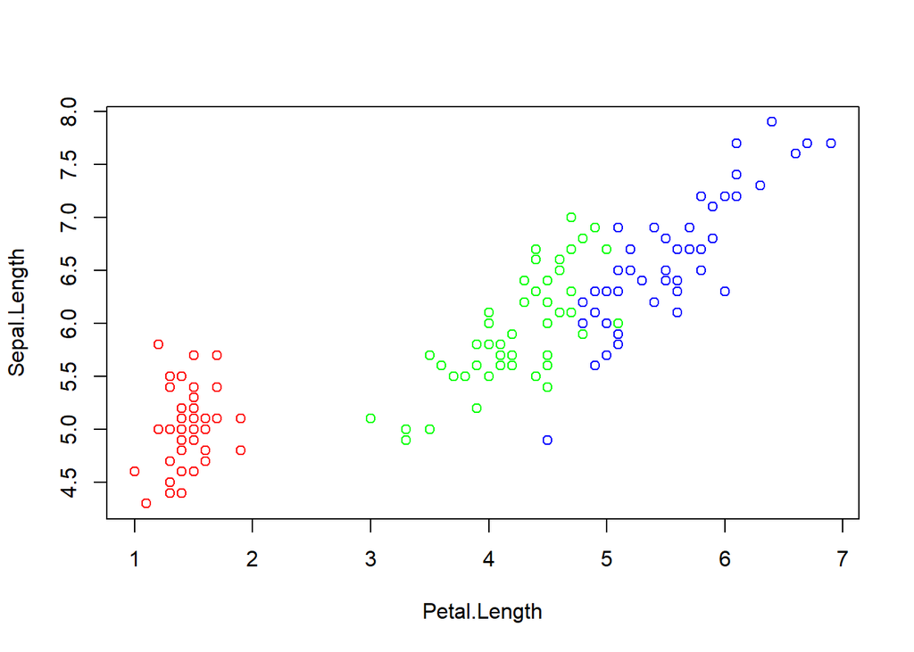

```r
palette(rainbow(3))
plot(iris$Petal.Length,iris$Sepal.Length,
     col=iris$Species,
     ylab="Sepal.Length",
     xlab="Petal.Length")
```

[figure not shown]

```r
plot(iris$Petal.Width,iris$Petal.Length,
    col=iris$Species,
    pch=as.numeric(iris$Species),
     ylab="Petal.Width",
     xlab="Petal.Length")
```

## Mosaico

¿Són independientes el sexo y la supervivencia en el hundimiento del Titanic?

```r
data("Titanic")
str(Titanic)
```

```
##  'table' num [1:4, 1:2, 1:2, 1:2] 0 0 35 0 0 0 17 0 118 154 ...
##  - attr(*, "dimnames")=List of 4
##   ..$ Class   : chr [1:4] "1st" "2nd" "3rd" "Crew"
##   ..$ Sex     : chr [1:2] "Male" "Female"
##   ..$ Age     : chr [1:2] "Child" "Adult"
##   ..$ Survived: chr [1:2] "No" "Yes"
```

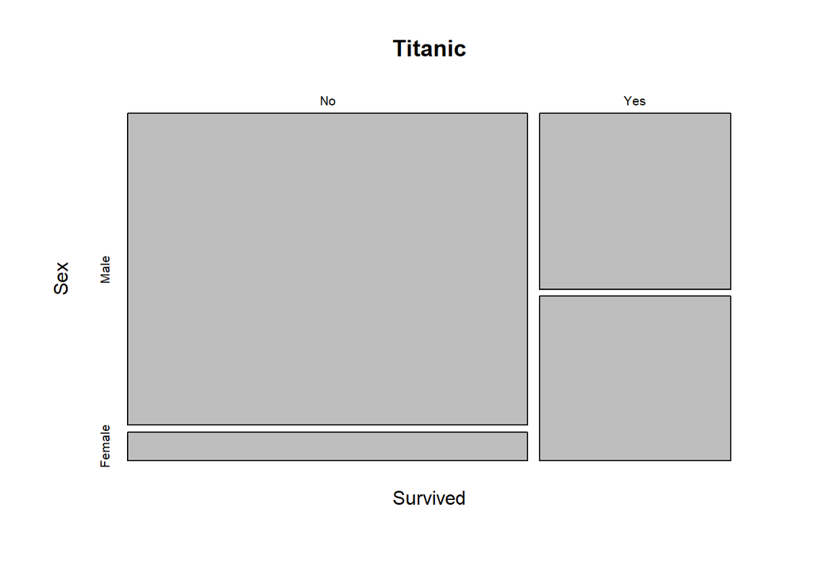

```r
mosaicplot(~Survived+Sex, data = Titanic)
```

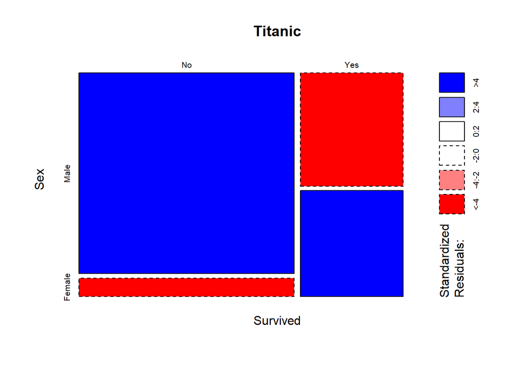

```r
#completar
mosaicplot(~Survived+Sex, data = Titanic, shade=TRUE)
```

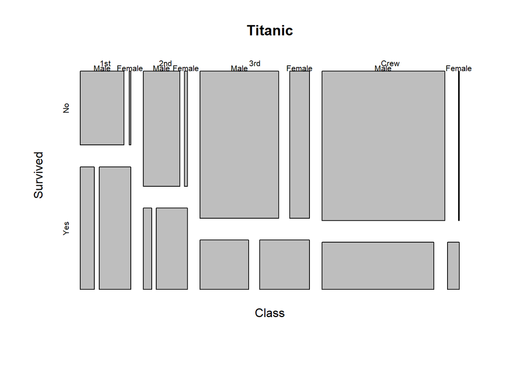

```r
mosaicplot(~Class+Survived+Sex, data = Titanic)
```

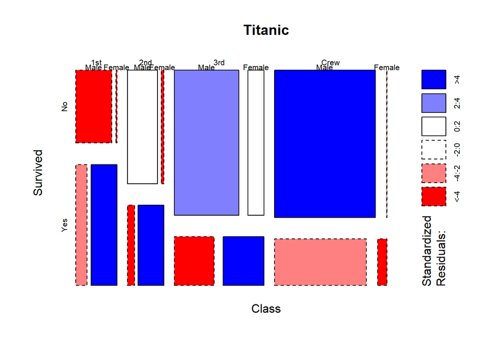

```r
mosaicplot(~Class+Survived+Sex, data = Titanic, shade=TRUE)
```